# Prediction of Quality of Performance for A Weight-Lifting Activity

Armen Abnousi

June 24, 2017

## Summary

The purpose of this project is to train a model to predict how well a dumbbell lifting activity is performed based on the various measurements that are obtained from some sensors. From different models that we train, we have selected random forest model (with boostraping and 100 trees) to be the most effective one (although it does not give the highest accuracy value, the results are very close and it requries shorter training time). We predict an out of sample accuracy of ~99%. We have used cross-validation and bootstrapping for different methods for fine-tuning the parameters of those models.

## Data Acquisition and Partitioning:

The dataset can be downloaded from [this link](https://d396qusza40orc.cloudfront.net/predmachlearn/pml-training.csv). The acquired data has more than 15,000 entries which can be considered a big dataset. Since we are asked to give an estimate of the accuracy of our model for out-of-sample data we break our dataset down to 3 partitions (i.e. training, validation and testing; a 60-20-20% split.).

```r
### splitting the data:
set.seed(123)
data <- read.csv("pml-training.csv", na.strings=c("NA", "#DIV/0!", " "))
inTrain <- createDataPartition(data$classe, p = 0.6, list = FALSE)
training <- data[inTrain,]
testing <- data[-inTrain,]
inTest <- createDataPartition(testing$classe, p = 0.5, list = FALSE)
validation <- testing[-inTest,]
testing <- testing[inTest,]
```

A simple exploration of the data reveals the persence of a multitude of missing data from the dataset. Generally two approaches can be taken when there are missing data in the dataset. One could either impute the missing data using various pre-processing methods or can ignore the missing data and work only with the ones that are present.

Since some of the columns have more than 90% of their entries missing, imputing the values for those columns might not be very accurate. So we decided to try training our model based only on the columns where all entries have their values. In addition, the first seven columns of the data do not contain useful information (columns like the name of the person performing the exercise or the date/timeframe). We remove these columns from our dataset too.

```r
### removing unwanted columns from the data:
training <- training[,-(1:7)]
fullCols <- (colSums(is.na(training)) == 0)
training <- training[, fullCols]
```

At the end of this steps we have a training set of 11776 rows and 53 columns. The size of the validation and testing sets are respectively 3923 and 3923.

## Training Different Models on the Training Set:

We train 9 different models on the training data. The models are listed below:

- random forest model with 25 bootstrapping samples and 100 trees
- random forest model with 0.632bootstrapping (25 samples) and 100 trees
- random forest model with 100 trees and using cross-validation for the selection of the randomly selected predictors; i.e. setting mtry parameter)
- random forest model with 100 trees and using repeated-cross-validation for the selection of the randomly selected predictors; i.e. setting mtry parameter)
- random forest model with 25 bootstrapping samples and 200 trees
- a single decision tree, fine-tuned using cross-validation for the complexity parameter (depth of the tree)
- Stochastic Gradient Boostign (gbm), fine-tuned for its parameters using bootstrapping
- Linear Discriminant Analysis (lda) (no fine-tuning required)
- random forest using 100 trees and boostrapping but using Principal Component Analysis

```r
#using 25 bootstraping samples
modelBoot <- train(classe~., data = training, method = "rf", ntree = 100, trControl = trainControl(method="boot"))
#using 25 bootstrap632
modelBoot632 <- train(classe~., data = training, method = "rf", ntree = 100, trControl = trainControl(method="boot632"))
#using 10-fold cross-validation on mtry (randomly selected predictors)
modelCv <- train(classe~., data = training, method = "rf", ntree = 100, trControl = trainControl(method="cv"))
#using 10-fold repeated cross-validation (10 repetition)
modelRepCv <- train(classe~., data = training, method = "rf", ntree = 100, trControl = trainControl(method="repeatedcv"))
#using larger number of trees
modelBoot200 <- train(classe~., data = training, method = "rf", ntree = 200, trControl = trainControl(method="boot"))
#using classification tree (rpart) with cross-validation for complexity parameter (depth of tree)
modelRpart <- train(classe~., data = training, method = "rpart", trControl = trainControl(method = "cv"))
#using gbm
modelGbm <- train(classe~., data = training, method = "gbm")
#using linear discreminant analysis
modelLda <- train(classe~., data = training, method = "lda")
#with pca
prep <- preProcess(training, method = c("pca"))
trainingPca <- predict(prep, training)
validationPca <- predict(prep, validation)
testingPca <- predict(prep, testing)
modelBootPca <- train(classe~., data = trainingPca, method = "rf", ntree = 100)
```

## Validation of the Trained Models:

After training our models on the training set, we use those models to predict the **classe** variable on the validation set. The results are shown below for each of those models:

```
##                       method       acc
## Accuracy         rf_boosting 0.9913332
## Accuracy1     rf_boosting632 0.9905684
## Accuracy2              rf_cv 0.9903135
## Accuracy3      rf_repeatedCV 0.9918430
## Accuracy4 rf_boosting200tree 0.9920979
## Accuracy5              rpart 0.5065001
## Accuracy6                GBM 0.9612541
## Accuracy7                LDA 0.6966607
## Accuracy8  rf_boosting_w_PCA 0.9676268
```

## Estimation of the out-of-sample Accuracy for the Selected Model:

Now that we have selected one model based on the validation set, we can use the testing set to give an estimate of our expected accuracy for the selected model when presented with new data:

```r
confusionMatrix(predict(modelBoot, testing), testing$classe)$overall[1]
```

```
##  Accuracy
## 0.9908233
```

We expect to have a 0.9908233 accuracy when presented with new data.

## Importance of the Predictors:

One benefit of using random forests (and trees) is that these models perform the feature selection automatically. However, we can use the **varImp** method to see the relative importance of the features used in the construction of the model. Here we show the importance of the top 10 features used in the construction of our selected model:

```r
v <- varImp(modelBoot)$importance
ord <- order(varImp(modelBoot)$importance, decreasing = TRUE)
vnames <- rownames(v)[ord]
v <- v[ord,]
data.frame(feature=vnames[1:10], importance=v[1:10])
```

```
##              feature importance
## 1          roll_belt  100.00000
## 2      pitch_forearm   61.50240
## 3           yaw_belt   57.89179
## 4  magnet_dumbbell_z   48.52201
## 5         pitch_belt   45.43879
## 6  magnet_dumbbell_y   44.56992
## 7       roll_forearm   41.52296
## 8   accel_dumbbell_y   20.91751
## 9      roll_dumbbell   20.06724
## 10   accel_forearm_x   17.90467
```

We can observe that roll_belt has the highest importance in our model. After this feature the next 6 features have relatively high importance with a big distance from the eighth important feature. To check the effectiveness of these important features, we construct a model using only the 7 most important predictors:

```r
selectedFeatures <- order(v$importance$Overall, decreasing = TRUE)[1:7]
selectTraining <- training[, selectedFeatures]
selectTraining <- cbind(selectTraining, classe=training$classe)
modelBootSelect <- train(classe~., data = selectTraining, method = "rf", ntree = 100, trControl = trainControl(method="boot"))
confusionMatrix(predict(modelBootSelect, validation), validation$classe)$overall[1]
```

```
##  Accuracy
## 0.9803722
```

We can see that the model trained using only the top 7 important features gives an accuracy of >98% on the validation set, while adding the rest of the 45 predictors improved the accuracy only by about 1%.

Another interesting observation is that the model trained using Principal Component Analysis had 0.9676268% accuracy while this model used 24 predictors (to capture 95% of the variance).

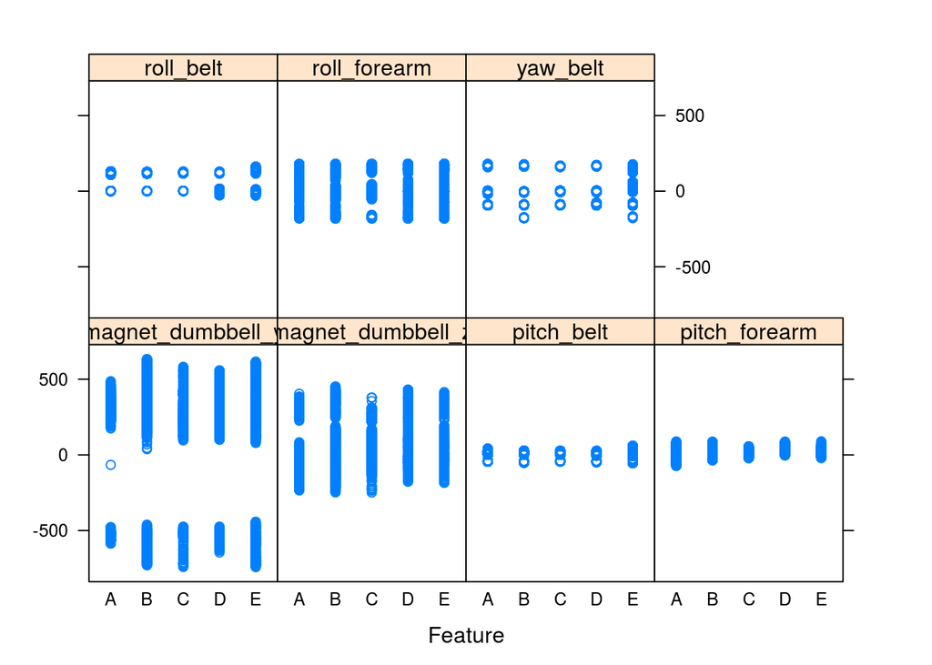

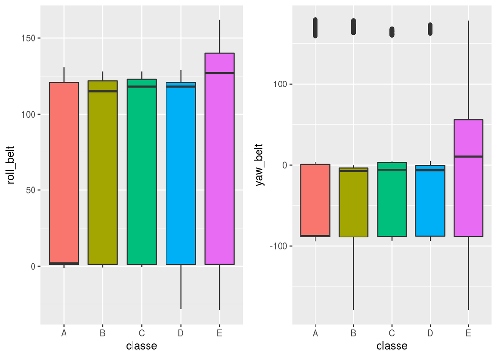

However, looking at the interaction of the these two variables reveals that if -80 < yaw_belt < -75, then if the roll_belt is greater than 10 or less than 2 it should be classified as D.

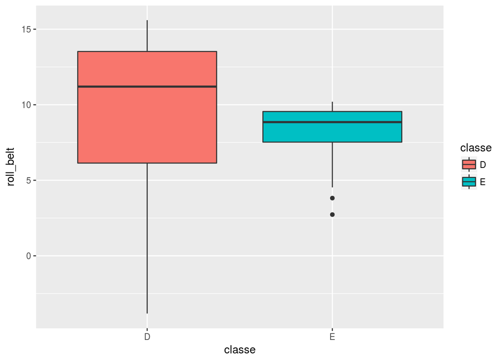

```r
ggplot(data = training[training$yaw_belt < -75 & training$yaw_belt > -80, ], aes(y = roll_belt, x = classe, fill = classe)) + geom_boxplot()
```